# Effect of the 2021 Virginia Minimum Wage Hike on the Employment Level of Food Service Workers in the State

By Jacob Langley

2023-01-08

# Abstract

- On May 1st 2021, Virginia raised its minimum wage from the federal minimum of $7.25 to $9.50 and again to $11.00 on January 1st 2022
- In the same timeframe Virginia’s neighbor, North Carolina, kept the federal minimum of $7.25

# Abstract

- This presentation will show that neither minimum wage hike has had a statistically significant effect on the employment level among food and beverage workers in Virginia thus far
- I use a Difference In Differences (DID) regression with North Carolina as a control, and logistic and lasso regressions for variable selection guidance

# Research Context

- According to a report by The Congressional Budget Office in 2019 an increase to a $15 minimum wage would raise 1.3 million people out of poverty but with a two thirds chance employment would decrease by anywhere between 0 and 3.7 million workers.
- 3.7 million would be about a 65% increase in the unemployment rate
- This potential employment loss statistic is so broad it conveys very little insight into whether or not raising the federal minimum wage is dangerous for the economy

# Research Context

- It is vital that economics as a field is able to give an answer when someone asks to what degree minimum wage hikes effect employment.
- The purpose of this project is to identify a specific example of a recent minimum wage change and give a more narrow response on it’s effect on the employment level.

# Research Context

### 2021 Economics Nobel Prize:

“Minimum Wages and Employment: A Case Study of the Fast-Food Industry in New Jersey and Pennsylvania” by David Card and Alan Krueger in 1994

- examined New Jersey’s minimum wage hike in 1992 from $4.25 to $5.05 and its effect on the employment level among fast food workers.
- The paper used a DID method to compare the employment level on either side of the NJ/PA border before and after the change

# Research Context

### What is DID Regression?

- DID regression takes a snapshot of the control and subject of the study before and after some treatment that is unique to the subject
- The method implies that if there is a significant divergence in the subject relative to the control after the treatment then the treatment caused that divergence.
- Uses cross sectional data to take advantage of “natural experiments” and is an analog to a traditional randomized controlled trial

# Research Context

- Taking inspiration from Card and Krueger, I have also utilized a DID analysis for this project
- My observations are on the county level where Card and Krueger’s observations were individual restaurants
- Like Card and Krueger, I used a neighbor state as the control

# Research Context

### Criticisms of Difference in Differences

- A 2019 paper by Bruno Ferman and Cristine Pinto was published criticizing DID as a method
- They challenged the prevailing assumption that having a large number of observations for each group satisfies the homoskedasticity requirement for multilinear regression
- They also suggested that if the treated group is much larger than the control, then DID would tend to under-reject the null hypothesis

# Research Context

### Criticisms of Difference in Differences

# Data

### Bureau of Labor Statistics

- employment level data for food and beverage retailers (445)
  - 2019 Q1
  - 2021 Q4
  - 2022 Q1

### US Census

- County Land Area
- Number of people with university degrees
  - US Census American Community Survey on Educational Attainment
  - 2020
- All Other Demographics
  - Calculated from County Population by Characteristics Dataset
  - 2019
  - 2021

# Data

Descriptive Statistics: Food Service Employment Level ($TotalVA = 133$ $TotalNC = 100$)

| Subset | N | Mean | StdDev | Min | Max |
| --- | --- | --- | --- | --- | --- |
| VA 2019 Q1 | 105 | 716 | 1382 | 19 | 11091 |
| VA 2021 Q4 | 98 | 805 | 1487 | 11 | 11776 |
| VA 2022 Q1 | 107 | 745 | 1447 | 10 | 11988 |
| NC 2019 Q1 | 84 | 1058 | 1818 | 20 | 11443 |
| NC 2021 Q4 | 82 | 1175 | 2008 | 12 | 12746 |
| NC 2022 Q1 | 84 | 1145 | 1993 | 10 | 12336 |

# Data

Descriptive Statistics: Education Data 2020 ($All 233 Counties$)

| Measure | Mean | StdDev | Min | Max |
| --- | --- | --- | --- | --- |
| Graduation Rate | 18.64 | 8.49 | 7.3 | 60.9 |

Descriptive Statistics: Data for Year 2019 ($All 233 Counties$)

| Measure | Mean | StdDev | Min | Max |
| --- | --- | --- | --- | --- |
| Average age (grouped) | 8.92 | 0.69 | 6.93 | 10.86 |
| Gender (1 = 100% women) | 0.51 | 0.02 | 0.37 | 0.54 |
| Percent White | 76.80 | 17.09 | 20.60 | 98.90 |
| Percent Black | 21.00 | 16.62 | 0.90 | 78.90 |
| Percent Hisp/Latino | 6.67 | 5.35 | 0.90 | 41.00 |
| Population Density | 579.77 | 1380.34 | 3.50 | 10365.90 |

# Data

Descriptive Statistics: Data for Year 2021 ($All 233 Counties$)

| Measure | Mean | StdDev | Min | Max |
| --- | --- | --- | --- | --- |
| Average age (grouped) | 8.93 | 0.70 | 6.96 | 10.80 |
| Gender (1 = 100% women) | 0.50 | 0.02 | 0.36 | 0.54 |
| Percent White | 76.64 | 17.03 | 20.40 | 98.80 |
| Percent Black | 21.08 | 16.52 | 1.00 | 79.10 |
| Percent Hisp/Latino | 7.10 | 5.50 | 1.00 | 43.00 |
| Population Density | 579.68 | 1358.68 | 3.20 | 10058.90 |

# Data

### The DID Dummies

- Control
  - 1 for VA
  - 0 for NC
- Time
  - 0 for Initial
  - 1 for Final
- Treatment
  - 1 for the VA after the treatment
  - 0 for all else

# Data

### Selection Bias Problem

Because of the large number of missing counties in the employment level data, selection bias may influence the results. Counties that do not have the resources to collect employment level data may be more rural with a lower average income and may be more exposed to a minimum wage hike.

# Research Design

### Directional Acyclic Graph

- The DAG contains my research assumptions for the major roots of the employment level in a typical western capitalist economy.
- Grey are roots whose data is not available to me
- Blue are roots that I did have datasets for

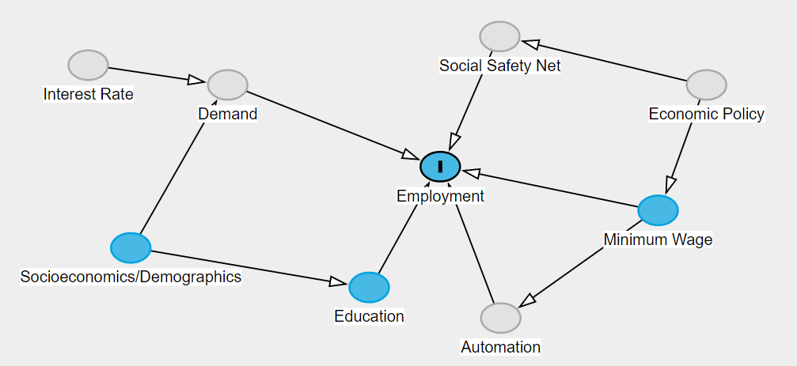

Unemployment DAG

# Research Design

- Both Virginia and North Carolina used the federal minimum wage until May 1st, 2021 when Virginia’s was raised to $9.50
- This created a natural experiment to compare Virginia with its neighbor to see if the hike had a effect on the state’s employment level

# Methodology

### Initial Regression

- A potential issue with the original DID model is that it is unclear how good of a control North Carolina is for Virginia. If they are very dissimilar then the predictors could just be alluding to the differences in employment between the two states. If that is the case then those variables would just be doing the job of the Control variable and would be redundant and unduly pulling significance away from the treatment variable.

# Methodology

### Variable Selection

- the main goal of the variable selection here is to identify which variables are good predictors of employment and not just proxies for the differences between the states
- The secondary goal of variable selection it to identify is Percent White or Percent White is more useful to the model since they connot both be included because of their high correlation (-96%)

# Methodology

### Logistic Regression

- Logistic regression is then utilized to identify which variables are good at discriminating between the two states
- If a variable is extremely good at discerning between the two states it wont be as clean of a predictor of employment in the final model

# Methodology

### Lasso Regression

- I can then take the results from the logistic regression and compare them with a regularization technique like lasso regression
- Lasso regression adds a punishment term and forces weaker predictors of the dependent variable to zero first
- Between the two we should get a good idea of which variables should be kept in the model for a stronger case